# Regressão linear na prática

## Dados da CAPES sobre avaliação da pós-graduação

A CAPES é um órgão do MEC que tem a atribuição de acompanhar a pós-graduação na universidade brasileira. Uma das formas que ela encontrou de fazer isso e pela qual ela é bastante criticada é através de uma avaliação quantitativa a cada x anos (era 3, mudou para 4).

Usaremos dados da penúltima avaliação da CAPES:

```r
cacc = read_projectdata()

glimpse(cacc)
```

```
## Observations: 73
## Variables: 31
## $ Instituição                  <chr> "UNIVERSIDADE FEDERAL DO AMAZONAS...
## $ Programa                     <chr> "INFORMÁTICA (12001015012P2)", "C...
## $ Nível                        <int> 5, 4, 3, 3, 3, 5, 4, 3, 3, 3, 5, ...
## $ Sigla                        <chr> "UFAM", "UFPA", "UFMA", "UEMA", "...
## $ `Tem doutorado`              <chr> "Sim", "Sim", "Não", "Não", "Não"...
## $ `Docentes colaboradores`     <dbl> 0.25, 5.50, 3.00, 6.25, 1.75, 2.0...
## $ `Docentes permanentes`       <dbl> 24.75, 14.00, 10.00, 14.00, 9.50,...
## $ `Docentes visitantes`        <dbl> 0.00, 0.00, 0.00, 0.00, 0.00, 0.7...
## $ `Resumos em conf`            <int> 20, 23, 15, 5, 4, 10, 6, 136, 0, ...
## $ `Resumos expandidos em conf` <int> 25, 24, 7, 10, 1, 68, 9, 13, 4, 6...
## $ `Artigos em conf`            <int> 390, 284, 115, 73, 150, 269, 179,...
## $ Dissertacoes                 <int> 108, 77, 50, 25, 31, 75, 60, 129,...
## $ Teses                        <int> 14, 0, 0, 0, 0, 24, 5, 0, 0, 0, 2...
```

[output cut: 18 more lines]

### Produção e produtividade de artigos

Uma das maneiras de avaliar a produção dos docentes que a CAPES utiliza é quantificando a produção de artigos pelos docentes. Os artigos são categorizados em extratos ordenados (A1 é o mais alto), e separados entre artigos em conferências e periódicos. Usaremos para esse lab a produção em periódicos avaliados com A1, A2 e B1.

```r
#converter para lower case
cacc$`Tem doutorado`  = tolower(cacc$`Tem doutorado`)

cacc = cacc %>%
  mutate(producao = (periodicos_A1 + periodicos_A2 + periodicos_B1),
         producao_aluno = (per_comaluno_A1 + per_comaluno_A2 + per_comaluno_B1),
         produtividade = producao / `Docentes permanentes`,
         prod_nivel = producao / Nível,
         prog_doutorado = ifelse(`Tem doutorado`== "sim", 1, 0),
         mestrados = Dissertacoes,
         doutorados = Teses,
         mestrados_pprof = mestrados / `Docentes permanentes`,
         doutorados_pprof = doutorados / `Docentes permanentes`)
```

### EDA

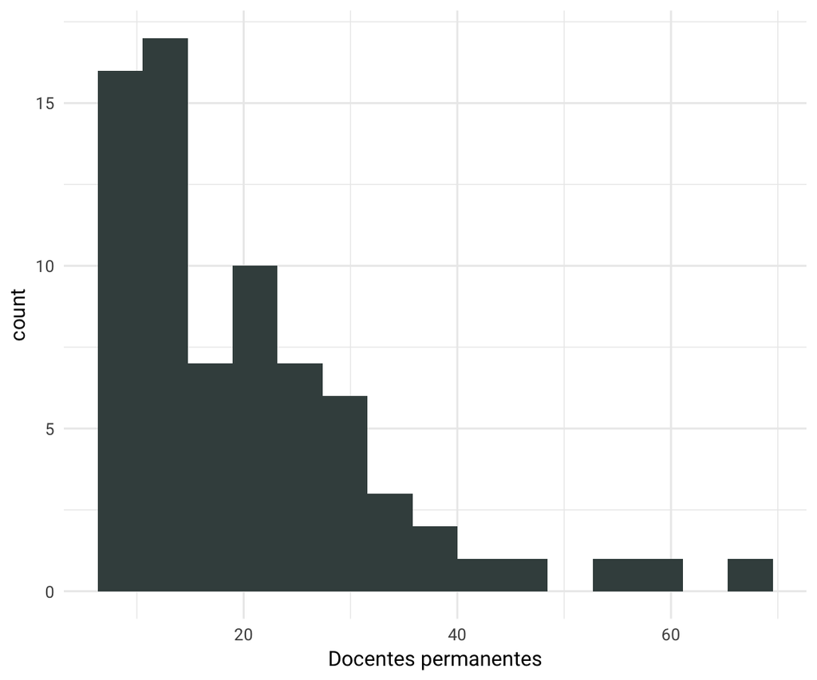

```r
cacc %>%
  ggplot(aes(x = `Docentes permanentes`)) +
  geom_histogram(bins = 15, fill = paleta[1])
```

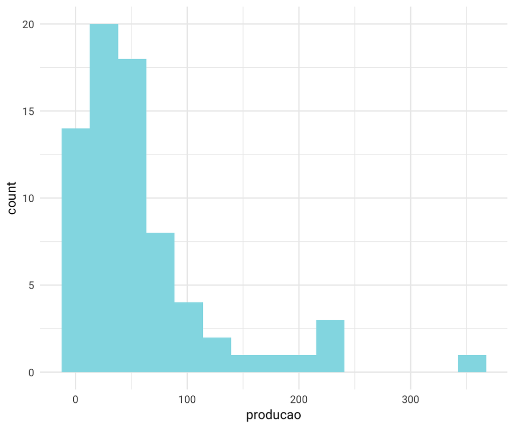

```r
cacc %>%
  ggplot(aes(x = producao)) +
  geom_histogram(bins = 15, fill = paleta[2])
```

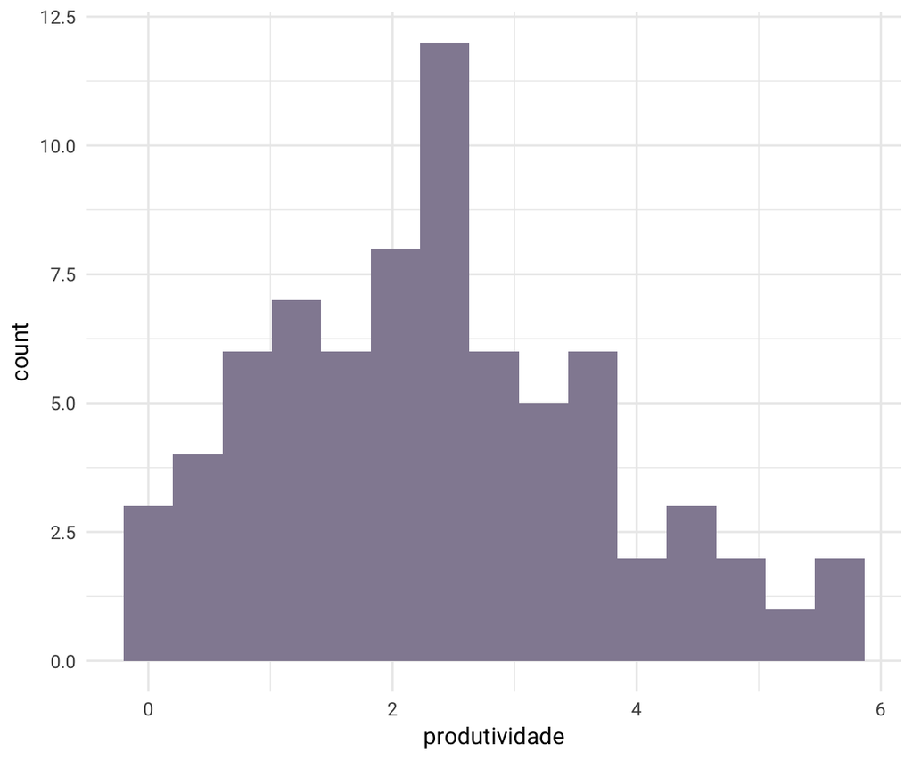

```r
cacc %>%
  ggplot(aes(x = produtividade)) +
  geom_histogram(bins = 15, fill = paleta[3])
```

Se quisermos modelar o efeito do tamanho do programa em termos de docentes (permanentes) na quantidade de artigos publicados, podemos usar regressão.

*Importante*: sempre queremos ver os dados antes de fazermos qualquer modelo ou sumário:

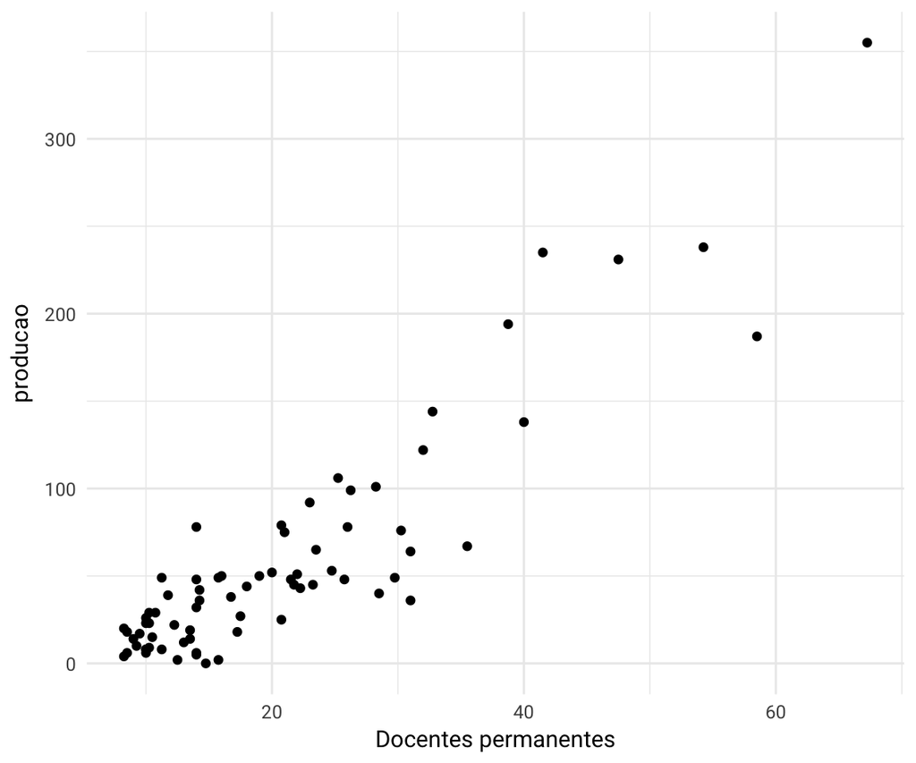

```r
cacc %>%
  ggplot(aes(x = `Docentes permanentes`, y = producao)) +
  geom_point()
```

Parece que existe uma relação. Vamos criar um modelo então:

```r
modelo1 = lm(producao ~ `Docentes permanentes`, data = cacc)

tidy(modelo1, conf.int = TRUE, conf.level = 0.95)
```

| term | estimate | std.error | statistic | p.value | conf.low | conf.high |
| --- | --- | --- | --- | --- | --- | --- |
| (Intercept) | -41.27309 | 6.5299245 | -6.320607 | 2.014731e-08 | -54.293387 | -28.252788 |
| `Docentes permanentes` | 4.81337 | 0.2725331 | 17.661601 | 1.088465e-27 | 4.269955 | 5.356786 |

```r
glance(modelo1)
```

| r.squared | adj.r.squared | sigma | statistic | p.value | df | logLik | AIC | BIC | deviance | df.residual |
| --- | --- | --- | --- | --- | --- | --- | --- | --- | --- | --- |
| 0.8145886 | 0.8119771 | 28.37407 | 311.9322 | 1.088465e-27 | 2 | -346.7883 | 699.5766 | 706.4479 | 57161.22 | 71 |

Para visualizar o modelo:

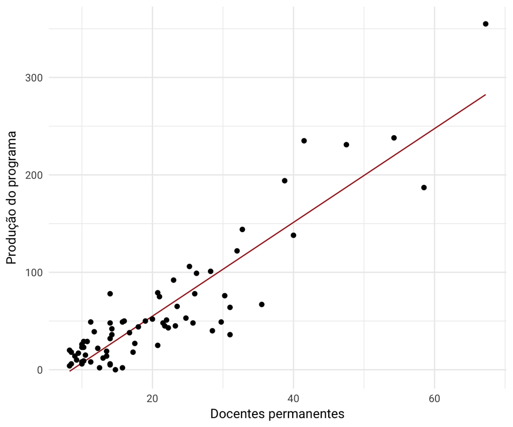

```r
cacc_augmented = cacc %>%
  add_predictions(modelo1)

cacc_augmented %>%
  ggplot(aes(x = `Docentes permanentes`)) +
  geom_line(aes(y = pred), colour = "brown") +
  geom_point(aes(y = producao)) +
  labs(y = "Produção do programa")
```

**Se considerarmos que temos apenas uma amostra de todos os programas de pós em CC no Brasil, o que podemos inferir a partir desse modelo sobre a relação entre número de docentes permanentes e produção de artigos em programas de pós?**

A Regressão linear foi utilizada para analisar se *quantidade de docentes permanentes* tem uma associação significativa com *produção do programa* de pós graduação, definido pela *quantidade de artigos publicados em períodicos com qualis A1, A2 e B1*. Os resultados da regressão indicam que um modelo com 1 preditor, apresentando *docentes permanentes* ($dpr$) como a variável independente e a *produção do programa* ($dpt$) como a variável dependente, no formato:
$$dpt = -41.27 + 4.81 \cdot dpr,$$
explica $81.46\%$ da variância da variável de resposta ($R^2 = 0.8146$). A variável $dpr$ (*quantidade de docentes permanentes*), tem uma relação significativa com o erro ($b = [4.27; 5.36]$, IC com $95\%$). O aumento de 1 unidade de $dpr$ produz uma mudança de mais ou menos $4.81$ em $dpt$, que pode ser verificado na associação do *valor estimado* à variável `Docentes permanentes`.

**Dito isso, o que significa a relação que você encontrou na prática para entendermos os programas de pós graduação no Brasil? E algum palpite de por que a relação que encontramos é forte?**

A relação entre produção bem avaliada e quantidade de docentes permamentes nos programas de pós graduação pode ser explicada em mais de 81%. Esse resultado é fortemente ligado, porque a quantidade de *papers* produzidos está intimamente ligada aos de projetos de pesquisa que são orientados pelos docentes permanentes. Também a orientação que esses docentes ministram aos seus orientados de doutorado. Se um aluno de doutorado ou mestrado publica um artigo, preferencialmente o nome do orientador, que na maioria das vezes é um docente permanente, deve está apresentado como um co-autoria de uma publicação. Esses dois palpites explicam o porquê dos docentes permanentes e alunos de doutorados apresentam uma associação forte nas publicações dos programas de pós-graduação.

## Mais fatores

E se considerarmos também o número de alunos?

```r
modelo2 = lm(producao ~ `Docentes permanentes` + mestrados + doutorados, data = cacc)

tidy(modelo2, conf.int = TRUE, conf.level = 0.95)
```

| term | estimate | std.error | statistic | p.value | conf.low | conf.high |
| --- | --- | --- | --- | --- | --- | --- |
| (Intercept) | -14.3663077 | 7.45407703 | -1.927309 | 5.805909e-02 | -29.2367845 | 0.5041691 |
| `Docentes permanentes` | 3.4997112 | 0.45965441 | 7.613788 | 1.015822e-10 | 2.5827257 | 4.4166967 |
| mestrados | -0.1949515 | 0.08159627 | -2.389221 | 1.962240e-02 | -0.3577316 | -0.0321714 |
| doutorados | 1.0007711 | 0.18309265 | 5.465927 | 6.874998e-07 | 0.6355112 | 1.3660309 |

```r
glance(modelo2)
```

| r.squared | adj.r.squared | sigma | statistic | p.value | df | logLik | AIC | BIC | deviance | df.residual |
| --- | --- | --- | --- | --- | --- | --- | --- | --- | --- | --- |
| 0.8706642 | 0.8650409 | 24.03905 | 154.8316 | 1.416348e-30 | 4 | -333.6422 | 677.2845 | 688.7368 | 39873.45 | 69 |

Visualizar o modelo com muitas variáveis independentes fica mais difícil

```r
para_plotar_modelo = cacc %>%
  data_grid(producao = seq_range(producao, 10), # Crie um vetor de 10 valores no range
            `Docentes permanentes` = seq_range(`Docentes permanentes`, 4),
            # mestrados = seq_range(mestrados, 3),
            mestrados = median(mestrados),
            doutorados = seq_range(doutorados, 3)) %>%
  add_predictions(modelo2)

glimpse(para_plotar_modelo)
```

```
## Observations: 120
## Variables: 5
## $ producao               <dbl> 0.00000, 0.00000, 0.00000, 0.00000, 0.0...
## $ `Docentes permanentes` <dbl> 8.25000, 8.25000, 8.25000, 27.91667, 27...
## $ mestrados              <int> 58, 58, 58, 58, 58, 58, 58, 58, 58, 58,...
## $ doutorados             <dbl> 0, 76, 152, 0, 76, 152, 0, 76, 152, 0, ...
## $ pred                   <dbl> 3.199123, 79.257725, 155.316327, 72.026...
```

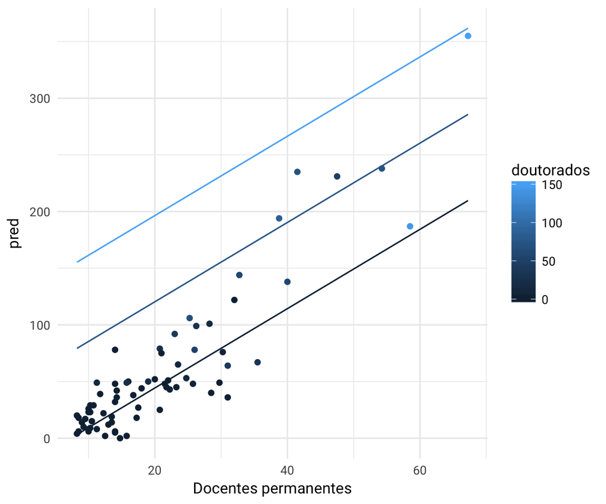

```r
para_plotar_modelo %>%
  ggplot(aes(x = `Docentes permanentes`, y = pred)) +
  geom_line(aes(group = doutorados, colour = doutorados)) +
  # facet_grid(. ~ as.factor(mestrados)) +
  geom_point(data = cacc, aes(y = producao, colour = doutorados))
```

Considerando agora esses três fatores, o que podemos dizer sobre como cada um deles se relaciona com a produção de um programa de pós em CC? E sobre o modelo? Ele explica mais que o modelo 1?

A Regressão múltipla foi utilizada para analisar se *quantidade de docentes permanentes*, *número de alunos de mestrado* e *número de alunos de doutorado* tem uma associação significativa com *produção do programa* de pós graduação, definido pela *quantidade de artigos publicados em períodicos com qualis A1, A2 e B1*. Os resultados da regressão indicam que um modelo com os 3 preditores, sendo *docentes permanentes* ($dpr$), *alunos de mestrado* ($amt$) e *alunos de doutorado* ($adt$) como a variável independente e a *produção do programa* ($dpt$) como a variável dependente, no formato:
$$dpt = -14.37 + 3.50 \cdot dpr - 0.20 \cdot amt + 1.001 \cdot adt,$$
explicam $87.07\%$ da variância da variável de resposta ($R^2 = 0.8707$). A variável $dpr$ (*quantidade de docentes permanentes*), tem uma relação significativa com o erro ($b = [2.58; 4.42]$, IC com $95\%$), assim como a variável $adt$ (*quantidade de alunos de doutorado*), tambem apresenta uma relação significativa com o erro ($b = [0.63; 1.37]$, IC com $95\%$). Entretando, a variável $amt$ (*quantidade de alunos de menstrado*), apresentou uma relação negativa, mas significativa com o erro ($b = [-0.36; -0.03]$, IC com $95\%$). O aumento de 1 unidade de $dpr$ produz uma mudança positiva de mais ou menos $3.5$ em $dpt$ e $1.001$ em $adt$. Entretanto, o aumento de 1 unidade de $dpr$ produz uma mudança de mais ou menos $-0,2$ em $amt$. Esses fatos podem ser verificado na associação do *valor estimado* às variáveis `Docentes permanentes`, `mestrados` e `doutorados`.

Comparando o modelo atual ao modelo anterior, temos um *R-squared* de $6\%$ a mais que o modelo 1. O modelo 2 explica $87\%$ da variância em $dpr$, enquanto o modelo 1 explica aproximadamente $81\%$ da variância em $dpr$. Dessa forma, concluimos que a influência das variáveis $adt$ e $amt$ apresentam uma melhoria no efeito do modelo em relação a produção do programa, principalmente a variável $adt$, que representam os alunos de doutorado, visto que os alunos de doutorado apresentam uma produção maior, fato que pode ser explicado pelo programa durar uma quantidade maior de anos que o programa de mestrado, e na pressão por produção acadêmica a esta categoria.

## Agora produtividade

Diferente de medirmos produção (total produzido), é medirmos produtividade (produzido / utilizado). Abaixo focaremos nessa análise. Para isso crie um modelo que investiga como um conjunto de fatores que você julga que são relevantes se relacionam com a produtividade dos programas. Crie um modelo que avalie como *pelo menos 3 fatores* se relacionam com a produtividade de um programa. Pode reutilizar fatores que já definimos e analizamos para produção. Mas cuidado para não incluir fatores que sejam função linear de outros já incluídos (ex: incluir A, B e um tercero C=A+B)

Produza abaixo o modelo e um texto que comente (i) o modelo, tal como os que fizemos antes, e (ii) as implicações - o que aprendemos sobre como funcionam programas de pós no brasil?.

```r
modelo3 = lm(produtividade ~ Nível + producao_aluno + prog_doutorado, data = cacc)

tidy(modelo3, conf.int = TRUE, conf.level = 0.95)
```

| term | estimate | std.error | statistic | p.value | conf.low | conf.high |
| --- | --- | --- | --- | --- | --- | --- |
| (Intercept) | 0.239664976 | 0.581618316 | 0.4120657 | 0.681568624 | -0.920631817 | 1.3999618 |
| Nível | 0.409035544 | 0.186558371 | 2.1925339 | 0.031716116 | 0.036861778 | 0.7812093 |
| producao_aluno | 0.007259461 | 0.005185224 | 1.4000286 | 0.165985180 | -0.003084777 | 0.0176037 |
| prog_doutorado | 0.860995787 | 0.292964121 | 2.9389121 | 0.004476383 | 0.276548356 | 1.4454432 |

```r
glance(modelo3)
```

| r.squared | adj.r.squared | sigma | statistic | p.value | df | logLik | AIC | BIC | deviance | df.residual |
| --- | --- | --- | --- | --- | --- | --- | --- | --- | --- | --- |
| 0.5743545 | 0.5558482 | 0.9146057 | 31.03558 | 8.170582e-13 | 4 | -95.00949 | 200.019 | 211.4713 | 57.71875 | 69 |

Sobre o modelo apresentado, podemos verificar que o nível do programa de pós graduação, a quantidade de publicações bem avaliadas por alunos e se a publicação é proveniente de uma universidade com programa de doutorado explicam $57\%$ da variância da produção de artigos bem avaliados. Dessa forma, concluimos que a influência das variáveis nível do programa e possui programa pós doutorado. A produção por aluno apresenta uma influência mínima na produtividade, enquanto as variáveis `prog_producao` e `Nível` apresentam alguma influência, respectivamente. A partir disso, podemos explicar os seguintes fatos: a relação entre a produtividade comparada ao nível de um programa de pós-graduação, será maior devido a pressão por produção acadêmica, visto que as universidades querem permanecer no *ranking* de melhores pós-graduações no Brasil. Também, a universidade apresentar um programa de doutorado, pode influenciar na produtividade, pois a cobrança por publicação são realizadas, em sua maioria, aos estudantes de doutorado.